# Лабораторная работа №5

Расширенная настройка HTTP-сервера Apache

Цыкунова Екатерина Михайловна

1132246732@rudn.ru

Российский университет дружбы народов

2026-09-23

# Цели и задачи работы

## Цель лабораторной работы

Целью данной работы является приобретение практических навыков расширенной настройки HTTP-сервера Apache: включение HTTPS, настройка PHP и подготовка сценария автоматической настройки для Vagrant.

## Задачи лабораторной работы

- сгенерировать закрытый ключ и самоподписанный сертификат;
- настроить виртуальный хост `www.emcikunova.net` для работы через HTTPS;
- разрешить HTTPS-трафик в `firewalld`;
- проверить переход с HTTP на HTTPS;
- установить и настроить PHP;
- создать страницу `index.php` с выводом информации о PHP;
- сохранить конфигурацию веб-сервера в каталог `provision`;
- скорректировать скрипт `http.sh`.

# Процесс выполнения лабораторной работы

## Генерирую ключ и самоподписанный сертификат

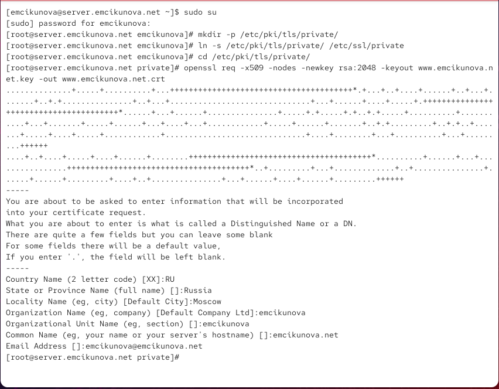

Генерация закрытого ключа RSA и сертификата X.509

## Настраиваю виртуальный хост для HTTPS

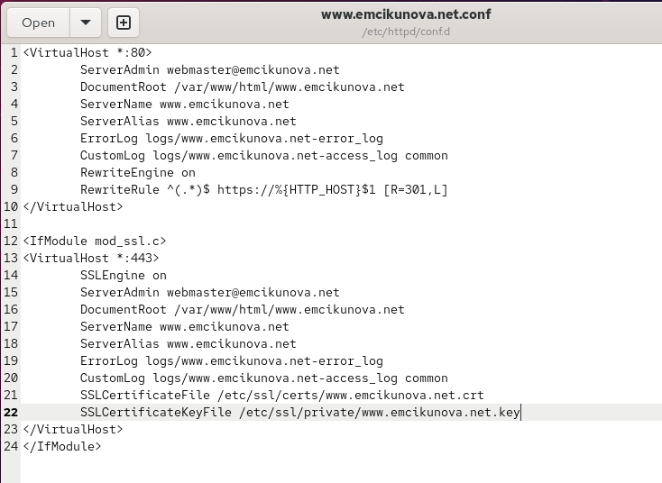

Конфигурация виртуального хоста www.emcikunova.net

## Разрешаю HTTPS в firewalld и перезапускаю Apache

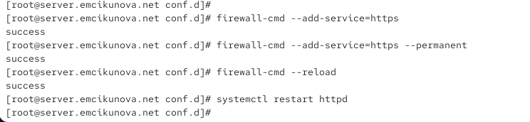

Настройка межсетевого экрана и перезапуск httpd

## Проверяю предупреждение о сертификате

[figure not shown]

Предупреждение браузера о самоподписанном сертификате

## Проверяю работу сайта через HTTPS

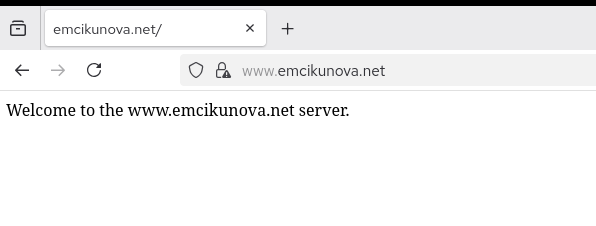

Открытие сайта www.emcikunova.net по HTTPS

## Просматриваю сведения о сертификате

[figure not shown]

Информация о самоподписанном сертификате

## Создаю PHP-страницу

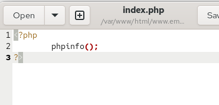

Создание файла index.php с вызовом phpinfo

## Настраиваю права и SELinux

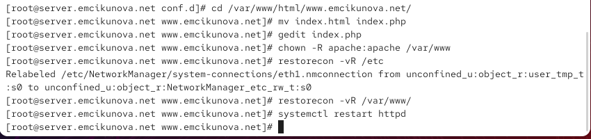

Настройка владельца файлов, SELinux и перезапуск Apache

## Проверяю работу PHP

[figure not shown]

Страница phpinfo на веб-сервере

## Сохраняю конфигурацию для Vagrant

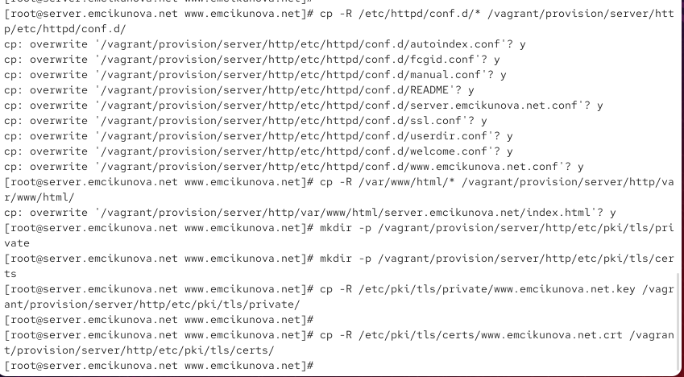

Копирование конфигурации, сертификата и ключа в каталог provision

## Корректирую сценарий автоматической настройки

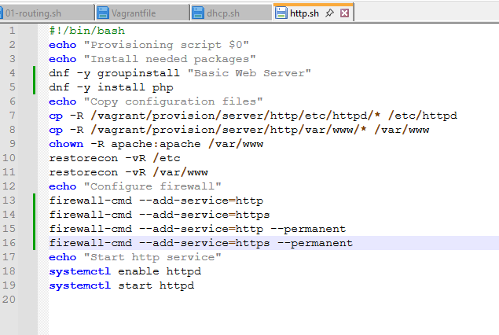

Скрипт http.sh для настройки Apache, PHP и HTTPS

## Вывод

В ходе лабораторной работы была выполнена расширенная настройка HTTP-сервера Apache.

Для виртуального хоста `www.emcikunova.net` был создан закрытый ключ и самоподписанный сертификат. В конфигурации Apache настроено перенаправление с HTTP на HTTPS, а в `firewalld` разрешена служба `https`.

Работа защищённого соединения была проверена с виртуальной машины `client`. Браузер выдал предупреждение о самоподписанном сертификате, после добавления исключения сайт успешно открылся через HTTPS.

Также была установлена поддержка PHP. Файл `index.php` с функцией `phpinfo()` подтвердил корректную обработку PHP-скриптов веб-сервером.

Конфигурация Apache, веб-контент, сертификат и ключ были сохранены в каталоге `provision`. Скрипт `http.sh` дополнен установкой PHP и настройкой HTTPS для автоматического развёртывания сервера.